# Appendix: Investigation of ‘No Response’ urban/rural classification and positive outcome gap

Author

Cristin Young

Published

March 2, 2026

**Note**

This report was generated using AI under general human direction. At the time of generation, the contents have not been comprehensively reviewed by a human analyst.

# Background

The `urban_rural` field in the EInsight data captures whether a client’s service location is classified as urban or rural. In addition to “Urban” and “Rural,” a large share of records carry the value “No Response for Urban Or Rural Selected” (referred to throughout as **No Response**). This appendix documents a systematic investigation of whether excluding No Response clients from urban/rural comparisons is defensible, and what the No Response group represents.

The motivating observation was a meaningful gap in positive outcome rates: No Response clients achieved positive outcomes at a lower rate than either Urban or Rural clients. This appendix traces what was and was not ruled out as an explanation for that gap.

# Data and setup

```r
library(tidyverse)
library(haven)
library(janitor)
library(broom)
library(ggrepel)
```

```r
all_data <- read_csv(
  "/Users/cristin/CWS Dropbox/Cristin Young/CYBHI Project/Rebecca and Tristan and Cristin/EInsight Data/demographic_discharge_clean.csv",
  show_col_types = FALSE
)

discharge_data <- read_csv(
  "/Users/cristin/CWS Dropbox/Cristin Young/CYBHI Project/Rebecca and Tristan and Cristin/EInsight Data/discharge_data_clean.csv",
  show_col_types = FALSE
)
```

```r
data201 <- all_data |>
  filter(
    !is.na(location),
    !is.na(pre_score),
    !is.na(post_score),
    !is.na(reason_for_discharge)
  ) |>
  mutate(positive_outcomes = factor(positive_outcomes, levels = c("No", "Yes"))) |>
  filter(intervention_start <= "2025-11-30")
```

```r
spss <- read_spss(
  "/Users/cristin/CWS Dropbox/Cristin Young/CYBHI Project/Data/MASTER Grantee Files/Quant Team File/MasterGranteeSpreadsheet_forBHESQuantTeam_1-20-26_NEW!.sav"
) |>
  zap_missing() |>
  mutate(across(where(is.labelled), as.character)) |>
  mutate(across(where(is.character), ~ na_if(str_trim(.x), ""))) |>
  rename_with(~ gsub("^@", "", .x)) |>
  clean_names() |>
  rename_with(~ gsub("^x", "", .x))

data201_spss <- left_join(
  data201, spss,
  by = c("provider" = "1a_grantee_provider_name", "provider_id" = "2grantee_provider_id")
) |>
  distinct(client_system_id, .keep_all = TRUE) |>
  rename(region = `8c_regions`)
```

```r
# Subset to Urban, Rural, and No Response
nr_vs_other <- data201_spss |>
  filter(!is.na(positive_outcomes)) |>
  mutate(
    ur_group = case_when(
      urban_rural == "No Response for Urban Or Rural Selected" ~ "No Response",
      urban_rural %in% c("Urban", "Rural")                    ~ urban_rural,
      TRUE                                                     ~ NA_character_
    )
  ) |>
  filter(!is.na(ur_group))

# Assessment tools with >= 50 total records
tools_to_keep <- nr_vs_other |>
  filter(!is.na(trimmed_pre_assessment_name)) |>
  count(trimmed_pre_assessment_name) |>
  filter(n >= 50) |>
  pull(trimmed_pre_assessment_name)

# Providers with a mix of No Response and Urban/Rural records (n >= 10)
provider_response <- nr_vs_other |>
  group_by(provider) |>
  summarise(
    total           = n(),
    n_no_response   = sum(ur_group == "No Response"),
    pct_no_response = n_no_response / total,
    .groups = "drop"
  ) |>
  filter(total >= 10)

mixed_providers <- provider_response |>
  filter(pct_no_response > 0, pct_no_response < 1) |>
  pull(provider)
```

# Overall outcome rates by urban/rural group

The first step was to establish the size of the outcome gap across the three groups, restricted to clients with valid outcome data.

```r
nr_vs_other |>
  group_by(ur_group) |>
  summarise(
    n            = n(),
    pct_positive = round(100 * mean(positive_outcomes == "Yes"), 1),
    .groups = "drop"
  ) |>
  arrange(desc(n)) |>
  rename(
    `Urban/rural group`  = ur_group,
    `N`                  = n,
    `% positive outcome` = pct_positive
  ) |>
  knitr::kable(caption = "Positive outcome rates by urban/rural classification")
```

Table 1: Positive outcome rates by urban/rural classification

| Urban/rural group | N | % positive outcome |
| --- | --- | --- |
| No Response | 4133 | 54.8 |
| Urban | 1774 | 61.7 |
| Rural | 666 | 76.1 |

No Response clients (n = 4133) had a notably lower positive outcome rate than Urban or Rural clients. The gap between No Response and Urban is approximately 6.9 percentage points.

# Is No Response a data collection artifact?

Before interpreting the outcome gap substantively, it was important to establish whether No Response is a meaningful population category or simply a reflection of inconsistent data entry.

```r
provider_response |>
  mutate(pattern = case_when(
    pct_no_response == 1 ~ "100% No Response",
    pct_no_response == 0 ~ "0% No Response (all Urban/Rural)",
    TRUE                 ~ "Mixed"
  )) |>
  count(pattern) |>
  rename(`Response pattern` = pattern, `Number of providers` = n) |>
  knitr::kable(caption = "Provider-level urban/rural response patterns (providers with n ≥ 10)")
```

Table 2: Provider-level urban/rural response patterns (providers with n ≥ 10)

| Response pattern | Number of providers |
| --- | --- |
| 0% No Response (all Urban/Rural) | 26 |
| 100% No Response | 24 |
| Mixed | 44 |

**Conclusion:** No Response is partly a data collection artifact. However, because nearly half of providers show mixed patterns, the outcome gap cannot be dismissed as purely a reporting issue. Subsequent analyses focus on the mixed-provider subset where within-provider comparison is possible.

# Ruling out dropout

One straightforward explanation for lower positive outcomes is higher dropout — clients who never complete treatment cannot show score improvement. Discharge reason distributions were compared across urban/rural groups within mixed providers.

```r
nr_vs_other |>
  filter(provider %in% mixed_providers) |>
  group_by(ur_group, reason_for_discharge) |>
  summarise(n = n(), .groups = "drop") |>
  group_by(ur_group) |>
  mutate(pct = round(100 * n / sum(n), 1)) |>
  ungroup() |>
  select(ur_group, reason_for_discharge, pct) |>
  pivot_wider(names_from = ur_group, values_from = pct) |>
  rename(`Reason for discharge` = reason_for_discharge) |>
  knitr::kable(caption = "Discharge reason distribution by urban/rural group (mixed providers, %)")
```

Table 3: Discharge reason distribution by urban/rural group (mixed providers, %)

| Reason for discharge | No Response | Rural | Urban |
| --- | --- | --- | --- |
| Clinically referred out | 2.9 | NA | 0.8 |
| Mutually agreed cessation of treatment (Successful Completion) | 92.1 | 97.4 | 95.4 |
| No Reason Selected | 1.3 | NA | 2.0 |
| No contact within 90 days of last session | 1.1 | 2.6 | 0.5 |
| Withdrew from/refused treatment | 2.6 | NA | 1.4 |

Dropout rates (withdrawal, no contact) are similar across groups. Mutually agreed cessation — the successful completion category — is slightly lower for No Response (92%) than Urban (95%) or Rural (97%), but the difference is modest.

To confirm that the outcome gap persists even among successful completers, positive outcome rates were compared within the mutually agreed cessation group:

```r
nr_vs_other |>
  filter(
    provider %in% mixed_providers,
    reason_for_discharge == "Mutually agreed cessation of treatment (Successful Completion)"
  ) |>
  group_by(ur_group) |>
  summarise(
    n            = n(),
    pct_positive = round(100 * mean(positive_outcomes == "Yes"), 1),
    .groups = "drop"
  ) |>
  rename(
    `Urban/rural group`  = ur_group,
    `N`                  = n,
    `% positive outcome` = pct_positive
  ) |>
  knitr::kable(caption = "Positive outcome rates among successful completers (mixed providers)")
```

Table 4: Positive outcome rates among successful completers (mixed providers)

| Urban/rural group | N | % positive outcome |
| --- | --- | --- |
| No Response | 1219 | 58.9 |
| Rural | 112 | 60.7 |
| Urban | 1009 | 64.0 |

**Conclusion:** The outcome gap is not driven by differential dropout. No Response clients who complete treatment still show a lower rate of score improvement than Urban completers (~59% vs. ~64%). Subsequent analyses focus on this score improvement gap.

# Outcome gap by assessment tool

The score improvement gap may not be uniform across assessment tools. Among successful completers in mixed providers, positive outcome rates were compared by tool.

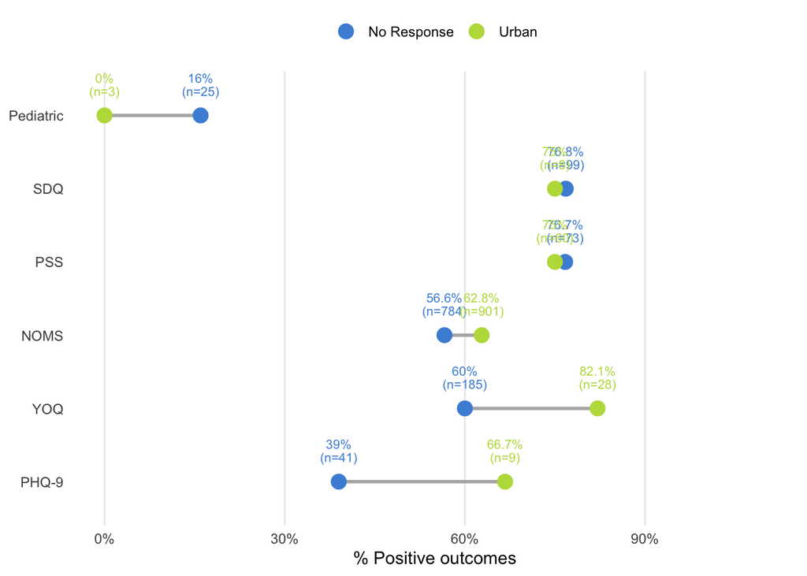

Figure 1: % positive outcomes by assessment tool: No Response vs. Urban (successful completers, mixed providers)

```r
tool_gap <- nr_vs_other |>
  filter(
    provider %in% mixed_providers,
    reason_for_discharge == "Mutually agreed cessation of treatment (Successful Completion)",
    trimmed_pre_assessment_name %in% tools_to_keep
  ) |>
  group_by(trimmed_pre_assessment_name, ur_group) |>
  summarise(
    n            = n(),
    pct_positive = round(100 * mean(positive_outcomes == "Yes"), 1),
    .groups = "drop"
  ) |>
  pivot_wider(names_from = ur_group, values_from = c(n, pct_positive)) |>
  clean_names() |>
  filter(!is.na(pct_positive_no_response), !is.na(pct_positive_urban)) |>
  mutate(
    gap  = pct_positive_no_response - pct_positive_urban,
    tool = fct_reorder(trimmed_pre_assessment_name, gap)
  )

tool_gap |>
  mutate(
    label_nr    = paste0(pct_positive_no_response, "%\n(n=", n_no_response, ")"),
    label_urban = paste0(pct_positive_urban,        "%\n(n=", n_urban,       ")")
  ) |>
  pivot_longer(
    cols      = c(pct_positive_no_response, pct_positive_urban),
    names_to  = "group",
    values_to = "pct_positive"
  ) |>
  mutate(
    group = if_else(group == "pct_positive_no_response", "No Response", "Urban"),
    label = if_else(group == "No Response", label_nr, label_urban)
  ) |>
  ggplot(aes(x = pct_positive, y = tool, color = group, group = tool)) +
  geom_line(color = "grey70", linewidth = 1) +
  geom_point(size = 4) +
  geom_text(
    aes(label = label),
    size = 2.8, lineheight = 0.85, vjust = -0.9, show.legend = FALSE
  ) +
  scale_color_manual(
    values = c("No Response" = "#4A90D9", "Urban" = "#BBDB49"),
    name   = NULL
  ) +
  scale_x_continuous(limits = c(0, 110), labels = \(x) paste0(x, "%")) +
  labs(x = "% Positive outcomes", y = NULL) +
  theme_minimal() +
  theme(
    panel.grid.minor   = element_blank(),
    panel.grid.major.y = element_blank(),
    legend.position    = "top"
  )
```

**Conclusion:** The gap is concentrated in PHQ-9 (No Response 39% vs. Urban 67%, −28 pp) and YOQ (60% vs. 82%, −22 pp). SDQ and PSS show near-zero gaps. Because PHQ-9 and YOQ are self-report symptom measures while SDQ and PSS are caregiver-report or parenting stress instruments, this pattern suggested the gap might reflect higher symptom severity at intake for No Response clients — which was tested in Section 10.

# Demographic profile of No Response clients

To assess whether No Response clients are a harder-to-reach population, demographic variables were compared across urban/rural groups within mixed providers.

```r
compare_demo <- function(var) {
  nr_vs_other |>
    filter(provider %in% mixed_providers) |>
    group_by(ur_group, value = .data[[var]]) |>
    summarise(n = n(), .groups = "drop") |>
    group_by(ur_group) |>
    mutate(pct = round(100 * n / sum(n), 1)) |>
    ungroup() |>
    mutate(variable = var)
}

map(c("insurance_status", "primary_language", "housing_status"), compare_demo) |>
  list_rbind() |>
  select(variable, ur_group, value, pct) |>
  pivot_wider(names_from = ur_group, values_from = pct) |>
  mutate(gap_nr_vs_urban = round(`No Response` - Urban, 1)) |>
  arrange(variable, desc(abs(gap_nr_vs_urban))) |>
  filter(!is.na(gap_nr_vs_urban)) |>
  rename(
    Variable      = variable,
    Category      = value,
    `Gap (NR − Urban)` = gap_nr_vs_urban
  ) |>
  knitr::kable(caption = "Demographic distribution by urban/rural group (mixed providers, %)")
```

Table 5: Demographic distribution by urban/rural group (mixed providers, %)

| Variable | Category | No Response | Rural | Urban | Gap (NR − Urban) |
| --- | --- | --- | --- | --- | --- |
| housing_status | Housed | 67.3 | 80.9 | 96.4 | -29.1 |
| housing_status | Not Applicable | 20.6 | NA | 1.3 | 19.3 |
| housing_status | Don’t Know | 5.2 | 2.6 | 0.7 | 4.5 |
| housing_status | Unhoused | 2.7 | 11.3 | 0.7 | 2.0 |
| housing_status | Prefer Not To Answer | 2.4 | 2.6 | 0.7 | 1.7 |
| housing_status | Other (i.e. treatment facility) | 0.6 | 2.6 | 0.1 | 0.5 |
| housing_status | NA | 0.3 | NA | 0.2 | 0.1 |
| insurance_status | Medi-Cal/Medi-Care | 29.6 | 35.7 | 49.3 | -19.7 |
| insurance_status | Not Applicable | 25.5 | 0.9 | 9.9 | 15.6 |
| insurance_status | Don’t Know | 30.2 | 40.0 | 22.7 | 7.5 |
| insurance_status | Private Insurance | 6.2 | 13.0 | 10.6 | -4.4 |
| insurance_status | Other | 3.7 | 1.7 | 0.9 | 2.8 |
| insurance_status | No insurance/Indigent | 2.3 | 5.2 | 4.2 | -1.9 |
| insurance_status | Prefer Not To Answer | 2.0 | 2.6 | 2.4 | -0.4 |
| primary_language | Spanish | 18.1 | 11.3 | 35.0 | -16.9 |
| primary_language | English | 74.2 | 88.7 | 61.3 | 12.9 |
| primary_language | Prefer Not To Answer | 3.4 | NA | 0.4 | 3.0 |
| primary_language | Chinese | 0.7 | NA | 0.2 | 0.5 |
| primary_language | Don’t Know | 0.9 | NA | 1.3 | -0.4 |
| primary_language | Korean | 0.1 | NA | 0.3 | -0.2 |
| primary_language | Hindi | 0.1 | NA | 0.2 | -0.1 |
| primary_language | No Primary Language Selected | 0.3 | NA | 0.2 | 0.1 |
| primary_language | Tagalog | 0.4 | NA | 0.3 | 0.1 |
| primary_language | Vietnamese | 0.1 | NA | 0.2 | -0.1 |

Notable differences:

- **Housing:** No Response clients have a much higher rate of “Not Applicable” (21% vs. 1% Urban), suggesting a distinct program type rather than housing instability.
- **Insurance:** No Response clients have lower Medi-Cal rates (30% vs. 49% Urban) and higher “Not Applicable” and “Don’t Know” rates, again pointing to program-type differences rather than economic disadvantage.
- **Language:** No Response clients are *less* likely to be Spanish-speaking (18% vs. 35% Urban) and more likely to speak English (74% vs. 61%), inconsistent with a harder-to-reach immigrant population explanation.

**Conclusion:** The demographic profile does not support the hypothesis that No Response clients are a more disadvantaged or harder-to-reach population. The pattern of elevated “Not Applicable” responses on both housing and insurance suggests that No Response providers serve structurally different client types.

# Client type and age

The “Not Applicable” pattern raised the question of whether No Response clients differ in client type (primary client vs. family member/caregiver reporter).

```r
nr_vs_other |>
  filter(provider %in% mixed_providers) |>
  mutate(age = as.numeric(age_at_start_of_treatment_in_years)) |>
  group_by(ur_group) |>
  summarise(
    n                  = n(),
    median_age         = median(age, na.rm = TRUE),
    pct_family_member  = round(100 * mean(primary_family_client == "Family Member", na.rm = TRUE), 1),
    .groups = "drop"
  ) |>
  rename(
    `Urban/rural group` = ur_group,
    `N`                 = n,
    `Median age (years)` = median_age,
    `% Family Member reporters` = pct_family_member
  ) |>
  knitr::kable(caption = "Age and client type by urban/rural group (mixed providers)")
```

Table 6: Age and client type by urban/rural group (mixed providers)

| Urban/rural group | N | Median age (years) | % Family Member reporters |
| --- | --- | --- | --- |
| No Response | 1323 | 17 | 4.0 |
| Rural | 115 | 16 | 3.5 |
| Urban | 1058 | 16 | 18.5 |

Urban clients are substantially more likely to be Family Member (caregiver) reporters (19%) compared to No Response (4%) and Rural (4%) clients. Age distributions are similar across groups.

# Logistic regression: independent predictors of positive outcomes

To assess whether client type independently predicts outcomes after accounting for urban/rural group, a logistic regression was fitted on the full dataset (not restricted to mixed providers).

```r
model_data <- data201_spss |>
  filter(
    !is.na(positive_outcomes),
    !is.na(primary_family_client),
    urban_rural %in% c("Urban", "Rural", "No Response for Urban Or Rural Selected")
  ) |>
  mutate(
    outcome_bin = as.integer(positive_outcomes == "Yes"),
    ur_group    = if_else(
      urban_rural == "No Response for Urban Or Rural Selected",
      "No Response", urban_rural
    ),
    ur_group    = factor(ur_group, levels = c("Urban", "Rural", "No Response")),
    client_type = factor(primary_family_client, levels = c("Primary Client", "Family Member"))
  )

fit <- glm(outcome_bin ~ client_type + ur_group, data = model_data, family = binomial)

tidy(fit, exponentiate = TRUE, conf.int = TRUE) |>
  filter(term != "(Intercept)") |>
  mutate(across(c(estimate, conf.low, conf.high), \(x) round(x, 2)),
         p.value = round(p.value, 3)) |>
  rename(
    Term        = term,
    OR          = estimate,
    `95% CI low`  = conf.low,
    `95% CI high` = conf.high,
    `p-value`   = p.value
  ) |>
  select(-statistic, -std.error) |>
  knitr::kable(caption = "Logistic regression: positive outcomes predicted by client type and urban/rural group")
```

Table 7: Logistic regression: positive outcomes predicted by client type and urban/rural group

| Term | OR | p-value | 95% CI low | 95% CI high |
| --- | --- | --- | --- | --- |
| client_typeFamily Member | 1.32 | 0.009 | 1.07 | 1.64 |
| ur_groupRural | 1.90 | 0.000 | 1.55 | 2.33 |
| ur_groupNo Response | 0.78 | 0.000 | 0.69 | 0.87 |

Both predictors are independently significant. Family Member reporters have 1.32× the odds of a positive outcome compared to Primary Clients (95% CI: 1.07–1.64, p = 0.009). However, the Rural advantage (OR = 1.9) and No Response disadvantage (OR = 0.78) both persist after adjustment, indicating that client type alone does not fully explain the urban/rural gaps.

# Baseline severity on PHQ-9 and YOQ

Given that the outcome gap was concentrated in PHQ-9 and YOQ (see above), a plausible explanation was that No Response clients present with higher symptom severity at intake, leaving less room for detectable improvement.

```r
nr_vs_other |>
  filter(
    provider %in% mixed_providers,
    trimmed_pre_assessment_name %in% c("PHQ-9", "YOQ"),
    ur_group %in% c("No Response", "Urban")
  ) |>
  mutate(pre_score = as.numeric(pre_score)) |>
  group_by(trimmed_pre_assessment_name, ur_group) |>
  summarise(
    n          = n(),
    mean_pre   = round(mean(pre_score, na.rm = TRUE), 1),
    median_pre = round(median(pre_score, na.rm = TRUE), 1),
    sd_pre     = round(sd(pre_score, na.rm = TRUE), 1),
    .groups    = "drop"
  ) |>
  rename(
    Tool       = trimmed_pre_assessment_name,
    Group      = ur_group,
    N          = n,
    Mean       = mean_pre,
    Median     = median_pre,
    SD         = sd_pre
  ) |>
  knitr::kable(caption = "Baseline (pre) score summary for PHQ-9 and YOQ by urban/rural group (mixed providers)")
```

Table 8: Baseline (pre) score summary for PHQ-9 and YOQ by urban/rural group (mixed providers)

| Tool | Group | N | Mean | Median | SD |
| --- | --- | --- | --- | --- | --- |
| PHQ-9 | No Response | 43 | 6.2 | 5 | 5.2 |
| PHQ-9 | Urban | 9 | 9.9 | 7 | 5.8 |
| YOQ | No Response | 191 | 23.8 | 24 | 16.2 |
| YOQ | Urban | 30 | 25.8 | 24 | 16.3 |

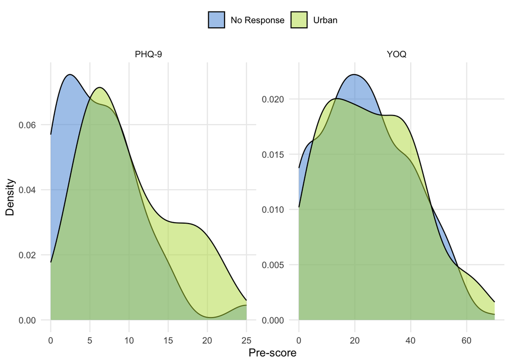

Figure 2: Baseline score distributions for PHQ-9 and YOQ: No Response vs. Urban (mixed providers)

```r
nr_vs_other |>
  filter(
    provider %in% mixed_providers,
    trimmed_pre_assessment_name %in% c("PHQ-9", "YOQ"),
    ur_group %in% c("No Response", "Urban")
  ) |>
  mutate(pre_score = as.numeric(pre_score)) |>
  ggplot(aes(x = pre_score, fill = ur_group)) +
  geom_density(alpha = 0.5) +
  facet_wrap(~ trimmed_pre_assessment_name, scales = "free") +
  scale_fill_manual(
    values = c("No Response" = "#4A90D9", "Urban" = "#BBDB49"),
    name   = NULL
  ) +
  labs(x = "Pre-score", y = "Density") +
  theme_minimal() +
  theme(
    panel.grid.minor = element_blank(),
    legend.position  = "top"
  )
```

**Conclusion:** The baseline severity hypothesis is not supported. For PHQ-9, No Response clients have *lower* average pre-scores than Urban clients (mean 6.2 vs. 9.9), suggesting a potential floor effect — clients starting near the minimum of the scale have less room to achieve a qualifying improvement. For YOQ, distributions are nearly identical. High baseline severity does not explain the gap.

# Intervention type as underlying driver

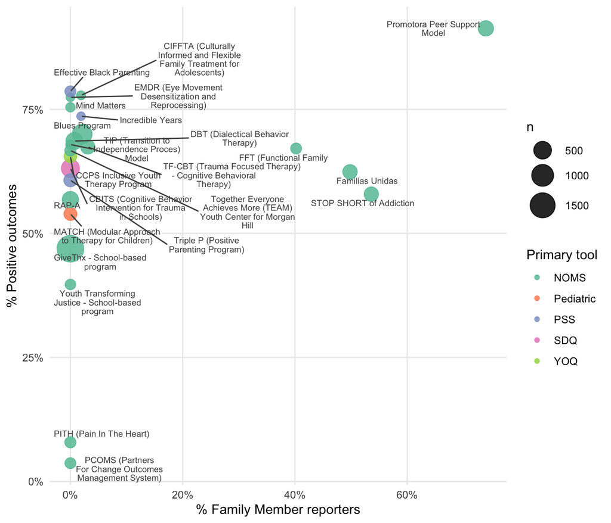

Figure 3: % Family Member reporters vs. % positive outcomes by intervention type (n ≥ 50)

```r
top_interventions <- data201_spss |>
  filter(!is.na(positive_outcomes), !is.na(intervention_name)) |>
  count(intervention_name) |>
  filter(n >= 50) |>
  pull(intervention_name)

intervention_summary <- data201_spss |>
  filter(
    !is.na(positive_outcomes),
    intervention_name %in% top_interventions,
    trimmed_pre_assessment_name %in% tools_to_keep
  ) |>
  group_by(intervention_name) |>
  summarise(
    n              = n(),
    pct_family_mbr = round(100 * mean(primary_family_client == "Family Member", na.rm = TRUE), 1),
    pct_positive   = round(100 * mean(positive_outcomes == "Yes"), 1),
    top_tool       = names(sort(table(trimmed_pre_assessment_name), decreasing = TRUE))[1],
    .groups = "drop"
  )

ggplot(intervention_summary,
       aes(x = pct_family_mbr, y = pct_positive, color = top_tool, size = n)) +
  geom_point(alpha = 0.85) +
  geom_text_repel(
    aes(label = str_wrap(intervention_name, 25)),
    size = 2.5, color = "grey30", lineheight = 0.85, max.overlaps = 15
  ) +
  scale_size_continuous(range = c(3, 10), name = "n") +
  scale_color_brewer(palette = "Set2", name = "Primary tool") +
  scale_x_continuous(labels = \(x) paste0(x, "%")) +
  scale_y_continuous(labels = \(x) paste0(x, "%")) +
  labs(
    x = "% Family Member reporters",
    y = "% Positive outcomes"
  ) +
  theme_minimal() +
  theme(
    panel.grid.minor = element_blank()
  )
```

**Conclusion:** Intervention type does not appear to drive the Family Member advantage through tool or reporter-type selection. The individual-level Family Member effect identified in Section 9 appears to reflect something about reporter engagement or family responsiveness rather than which intervention was delivered.

# Summary of findings

The table below summarises each candidate explanation for the No Response outcome gap and its evidential status.

| Candidate explanation | Verdict | Key evidence |
| --- | --- | --- |
| Data collection artifact (systematic non-reporters) | **Partial** | 24 providers (100% No Response); Statewide county drives ~1,800 records |
| Higher dropout / disengagement | **Ruled out** | Discharge reason distributions similar; gap persists among completers |
| Greater demographic hardship | **Ruled out** | No Response clients are less likely to be Spanish-speaking; lower Medi-Cal; more “Not Applicable” |
| Higher baseline symptom severity | **Ruled out** | PHQ-9 No Response clients start *lower*, not higher; YOQ distributions nearly identical |
| Client type (Family Member vs. Primary Client) | **Partial contributor** | Family Members have OR = 1.32 for positive outcomes; Urban clients have more Family Members (19% vs. 4%). Does not fully explain gap. |
| Intervention or tool type | **Ruled out** | NOMS dominates across interventions; no clean intervention-level pattern |
| Floor effect on PHQ-9 | **Plausible, untested** | No Response PHQ-9 clients start at lower scores with less room to improve |
| Provider-level factors | **Plausible, untested** | Within mixed providers, gap is consistent but origin unclear |

# Open questions

The following questions were not resolved by this analysis and represent natural next steps:

1. **Floor effect on PHQ-9:** If No Response clients start near the minimum of the PHQ-9 scale, the positive outcome threshold (requiring a qualifying score *decrease*) may rarely be met regardless of clinical progress. Examining the distribution of pre-scores relative to the scoring threshold would clarify this.
2. **Provider-level factors:** Even within mixed providers, No Response clients have systematically worse outcomes. Understanding what distinguishes these clients within a provider — whether it is a specific program strand, referral pathway, or intake process — would require provider-level consultation.
3. **Analytic treatment:** Given the findings above, we recommend against pooling No Response clients with Urban or Rural in location-based analyses. The most defensible approach is either (a) to exclude No Response clients from urban/rural comparisons entirely, with a note about the systematic non-reporters, or (b) to treat No Response as a separate category with appropriate caveats about its composition.